# main

## 📃 Abstract

### Generative Adversarial Networks (GANs) have been widely used for synthesizing new images from various datasets. In this project, we explore the use of GANs for synthesizing new images from the CIFAR-10 dataset. The CIFAR-10 dataset contains 60,000 32x32 color images in 10 classes, which makes it an ideal dataset for exploring the potential of GANs. Our aim is to train a GAN to generate new images that are similar to the ones in the CIFAR-10 dataset, while still being diverse and unique. We compare the results of different GAN architectures, such as DCGAN and WGAN, to determine the best model for generating new images from the CIFAR-10 dataset. Our results demonstrate the potential of GANs in synthesizing high-quality images from the CIFAR-10 dataset, and highlight the importance of choosing the right GAN architecture for the task at hand. This study provides insights into the potential applications of GANs in image synthesis and generation.

[figure not shown]

## ↪️ File directory

| File | Description |
| --- | --- |
| 📁data/* | Downloaded CIFAR-10 dataset |
| 📁model_saves/* | Saved weights of each model in its separate folders |
| 📁notebooks/* | Python notebooks used to run the models |
| └📓acgan.ipynb | notebook used to run acgan model |
| └📓c-dcgan.ipynb | notebook used to run c-dcgan model |
| └📓dcgan.ipynb | notebook used to run dcgan model |
| └📓simple_baseline.ipynb | notebook used to run simple baseline model |
| └📓wgan.ipynb | notebook used to run wgan model |
| └🐍utils.py | utils to run train function and weight initialisation |
| └📁models/* | description |
| └🐍acgan.py | Contains discriminator and generator classes for acgan |
| └🐍cdcgan.py | Contains discriminator and generator classes for cdcgan |
| └🐍dcgan.py | Contains discriminator and generator classes for dcgan |
| └🐍wgan.py | Contains discriminator and generator classes for wgan |
| └🐍simple_baseline.py | Contains discriminator and generator classes for simple baseline |
| 📓main.ipynb | Main python notebook which includes EDA and summary of results |

## 🛍️ Importing torch libraries and setting hyperparameters

```python
import os
import numpy as np
import tensorflow as tf
import torch
import torchvision
import torch.nn as nn
import torch.optim as optim
import torch.nn.functional as F
import torchvision.datasets as datasets
import torchvision.transforms as transforms
from torch.utils.data import DataLoader, random_split
from torchvision.datasets import CIFAR10
from torchmetrics.image.fid import FrechetInceptionDistance

import matplotlib.pyplot as plt

random_seed = 9292
torch.manual_seed(random_seed)
LATENT_DIM = 100
BATCH_SIZE = 64
NUM_EPOCHS = 500
AVAIL_GPUS = min(1, torch.cuda.device_count())
NUM_WORKERS = int(os.cpu_count() / 2)
lr = 3e-4
latent_dims = 100
device = "cuda" if torch.cuda.is_available() else "cpu"
```

## Loading data

### Since we will be using an activation layer of Tanh for the last layer of the generator, which maps the data from -1 to 1, The data will be preprocessed by normalizing the images from -1 to 1 using the transforms.Normalize().

```python
data_dir = './data'

transform = transforms.Compose([
    transforms.ToTensor(),
    transforms.Normalize((0.5, 0.5, 0.5), (0.5, 0.5, 0.5))
])

training = CIFAR10(data_dir, train=True, transform=transform, download=True)
testing = CIFAR10(data_dir, train=False, transform=transform, download=True)

train_dataloader = DataLoader(training, batch_size=BATCH_SIZE, num_workers=NUM_WORKERS)
test_dataloader = DataLoader(testing, batch_size=BATCH_SIZE, num_workers=NUM_WORKERS)
```

```
Files already downloaded and verified
Files already downloaded and verified
```

## 🔬 EDA

### The images are very small (32x32) but represent a wide variety of animals and objects. There are similar classes though, with there being classes like 'cat' and 'dogs', and 'truck' and 'automobile'. In this notebook we are going to build several GAN models to replicate a collection of images with ten classes:

```
Airplane
Automobile
Bird
Cat
Deer
Dog
Frog
Horse
Ship
Truck
```

```
torch.Size([3, 32, 32])
```

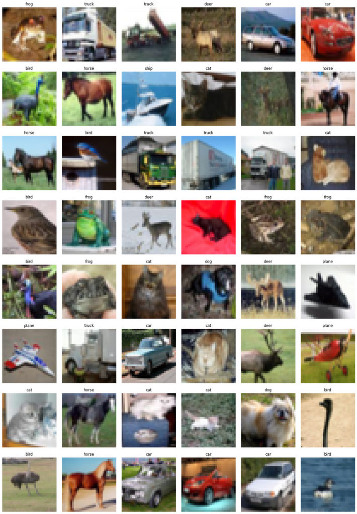

```python
classes = ('plane', 'car', 'bird', 'cat', 'deer', 'dog', 'frog', 'horse', 'ship', 'truck')
rows = 8
columns = 6
for data, label in train_dataloader:
    fig, axs = plt.subplots(rows, columns, figsize=(20, 30))
    for i in range(rows*columns):
        ax = axs[i//columns, i%columns]
        img = (data[i].permute(1,2,0) + 1) / 2
        ax.imshow(img, cmap='Greys')
        ax.axis('off')
        classlabel = classes[label[i]]
        ax.set_title(classlabel)

    print(data[0].shape)
    break


plt.subplots_adjust(wspace=0.1, hspace=0)
```

## 📊 Class distribution

### The CIFAR-10 dataset consists of 60,000 32x32 color images in 10 classes, with 6,000 images per class. There are 50,000 training images and 10,000 test images. The classes are equally balanced, with each class containing 6,000 images. The mean pixel value across the train and test set is approximately -0.05 and -0.04. The pixel values range from -1 to 1.

```python
from collections import Counter

train_classes_collated, test_classes_collated = [], []
train_img_avg, test_img_avg = [], []

for img, label in train_dataloader:
    train_classes_collated += label
    train_img_avg.append(torch.mean(img).item())

for img, label in test_dataloader:
    test_classes_collated += label
    test_img_avg.append(torch.mean(img).item())

train_classes_collated = [label.item() for label in train_classes_collated]
test_classes_collated = [label.item() for label in test_classes_collated]

train_img_avg =  sum(train_img_avg) / len(train_img_avg)
test_img_avg = sum(test_img_avg) / len(test_img_avg)

train_counter_object = Counter(train_classes_collated)
test_counter_object = Counter(test_classes_collated)
```

```python
print(f'Average pixel value (train set): {train_img_avg}')
print(f'Average pixel value (test set): {test_img_avg}')
```

```
Average pixel value (train set): -0.05313632174027617
Average pixel value (test set): -0.046853012103545866
```

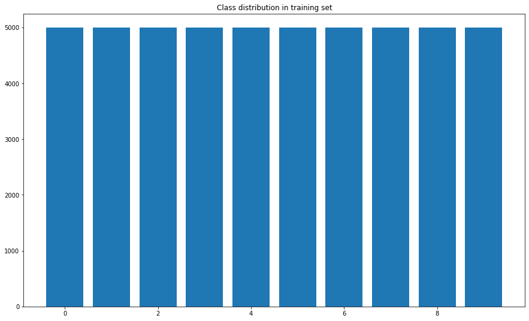

```python
plt.figure(figsize=(15,9))
plt.bar(train_counter_object.keys(), train_counter_object.values())
plt.title('Class distribution in training set')
plt.show()
```

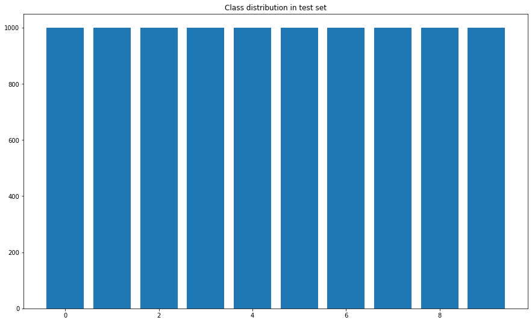

```python
plt.figure(figsize=(15,9))
plt.bar(test_counter_object.keys(), test_counter_object.values())
plt.title('Class distribution in test set')
plt.show()
```

## 🤖 Models used

### Simple baseline

[figure not shown]

```python
from torchsummary import summary
from notebooks.models.simple_baseline import SimpleDiscriminator, SimpleGenerator

G = SimpleGenerator(100).to(device)
D = SimpleDiscriminator().to(device)

summary(D, (3, 32, 32))
```

```
----------------------------------------------------------------
        Layer (type)               Output Shape         Param #
================================================================
            Linear-1                 [-1, 1024]       3,146,752
         LeakyReLU-2                 [-1, 1024]               0
            Linear-3                  [-1, 512]         524,800
         LeakyReLU-4                  [-1, 512]               0
            Linear-5                  [-1, 128]          65,664
         LeakyReLU-6                  [-1, 128]               0
            Linear-7                   [-1, 64]           8,256
         LeakyReLU-8                   [-1, 64]               0
            Linear-9                   [-1, 32]           2,080
        LeakyReLU-10                   [-1, 32]               0
           Linear-11                    [-1, 1]              33
          Sigmoid-12                    [-1, 1]               0
================================================================
Total params: 3,747,585
Trainable params: 3,747,585
Non-trainable params: 0
----------------------------------------------------------------
Input size (MB): 0.01
Forward/backward pass size (MB): 0.03
Params size (MB): 14.30
Estimated Total Size (MB): 14.33
----------------------------------------------------------------
```

```python
summary(G, (1, 100))
```

```
----------------------------------------------------------------
        Layer (type)               Output Shape         Param #
================================================================
            Linear-1               [-1, 1, 256]          25,856
              ReLU-2               [-1, 1, 256]               0
            Linear-3               [-1, 1, 512]         131,584
              ReLU-4               [-1, 1, 512]               0
            Linear-5              [-1, 1, 1024]         525,312
              ReLU-6              [-1, 1, 1024]               0
            Linear-7              [-1, 1, 2048]       2,099,200
              ReLU-8              [-1, 1, 2048]               0
            Linear-9              [-1, 1, 3072]       6,294,528
             Tanh-10              [-1, 1, 3072]               0
================================================================
Total params: 9,076,480
Trainable params: 9,076,480
Non-trainable params: 0
----------------------------------------------------------------
Input size (MB): 0.00
Forward/backward pass size (MB): 0.11
Params size (MB): 34.62
Estimated Total Size (MB): 34.73
----------------------------------------------------------------
```

### DCGAN

[figure not shown]

```python
from notebooks.models.DCGAN import DCGANDiscriminator, DCGANGenerator

G = DCGANGenerator(100).to(device)
D = DCGANDiscriminator().to(device)

summary(D, (3, 32, 32))
```

```
----------------------------------------------------------------
        Layer (type)               Output Shape         Param #
================================================================
            Conv2d-1          [-1, 128, 16, 16]           6,272
            Conv2d-2            [-1, 256, 8, 8]         524,544
       BatchNorm2d-3            [-1, 256, 8, 8]             512
            Conv2d-4            [-1, 512, 4, 4]       2,097,664
       BatchNorm2d-5            [-1, 512, 4, 4]           1,024
            Conv2d-6              [-1, 1, 1, 1]           8,193
================================================================
Total params: 2,638,209
Trainable params: 2,638,209
Non-trainable params: 0
----------------------------------------------------------------
Input size (MB): 0.01
Forward/backward pass size (MB): 0.63
Params size (MB): 10.06
Estimated Total Size (MB): 10.70
----------------------------------------------------------------
```

```python
summary(G, (1, 100))
```

```
----------------------------------------------------------------
        Layer (type)               Output Shape         Param #
================================================================
   ConvTranspose2d-1           [-1, 1024, 4, 4]       1,639,424
       BatchNorm2d-2           [-1, 1024, 4, 4]           2,048
   ConvTranspose2d-3            [-1, 512, 8, 8]       8,389,120
       BatchNorm2d-4            [-1, 512, 8, 8]           1,024
   ConvTranspose2d-5          [-1, 128, 16, 16]       1,048,704
       BatchNorm2d-6          [-1, 128, 16, 16]             256
   ConvTranspose2d-7            [-1, 3, 32, 32]           6,147
================================================================
Total params: 11,086,723
Trainable params: 11,086,723
Non-trainable params: 0
----------------------------------------------------------------
Input size (MB): 0.00
Forward/backward pass size (MB): 1.27
Params size (MB): 42.29
Estimated Total Size (MB): 43.57
----------------------------------------------------------------
```

### Conditional DCGAN

#### First run, learning rate set to 3e-4 for both models

[figure not shown]

#### Second run, same hyperparameters

[figure not shown]

#### third run, learning rate is the same, except the generator gets trained twice more

[figure not shown]

#### four

[figure not shown]

#### five

[figure not shown]

#### six

[figure not shown]

#### seven

[figure not shown]

#### eight

[figure not shown]

### ACGAN

[figure not shown]

```python
from notebooks.models.acgan import ACGANDiscriminator, ACGANGenerator

G = ACGANGenerator(100).to(device)
D = ACGANDiscriminator().to(device)

summary(D, [(3, 32, 32)])
```

```
----------------------------------------------------------------
        Layer (type)               Output Shape         Param #
================================================================
            Conv2d-1           [-1, 16, 16, 16]             432
         LeakyReLU-2           [-1, 16, 16, 16]               0
           Dropout-3           [-1, 16, 16, 16]               0
            Conv2d-4           [-1, 32, 16, 16]           4,608
       BatchNorm2d-5           [-1, 32, 16, 16]              64
         LeakyReLU-6           [-1, 32, 16, 16]               0
           Dropout-7           [-1, 32, 16, 16]               0
            Conv2d-8             [-1, 64, 8, 8]          18,432
       BatchNorm2d-9             [-1, 64, 8, 8]             128
        LeakyReLU-10             [-1, 64, 8, 8]               0
          Dropout-11             [-1, 64, 8, 8]               0
           Conv2d-12            [-1, 128, 8, 8]          73,728
      BatchNorm2d-13            [-1, 128, 8, 8]             256
        LeakyReLU-14            [-1, 128, 8, 8]               0
          Dropout-15            [-1, 128, 8, 8]               0
           Conv2d-16            [-1, 256, 4, 4]         294,912
      BatchNorm2d-17            [-1, 256, 4, 4]             512
        LeakyReLU-18            [-1, 256, 4, 4]               0
          Dropout-19            [-1, 256, 4, 4]               0
           Conv2d-20            [-1, 512, 4, 4]       1,179,648
      BatchNorm2d-21            [-1, 512, 4, 4]           1,024
        LeakyReLU-22            [-1, 512, 4, 4]               0
          Dropout-23            [-1, 512, 4, 4]               0
           Linear-24                    [-1, 1]           8,193
           Linear-25                   [-1, 10]          81,930
          Softmax-26                   [-1, 10]               0
          Sigmoid-27                    [-1, 1]               0
================================================================
Total params: 1,663,867
Trainable params: 1,663,867
Non-trainable params: 0
----------------------------------------------------------------
Input size (MB): 0.01
Forward/backward pass size (MB): 1.09
Params size (MB): 6.35
Estimated Total Size (MB): 7.45
----------------------------------------------------------------
```

```python
summary(G, (1, 100))
```

```
----------------------------------------------------------------
        Layer (type)               Output Shape         Param #
================================================================
            Linear-1                  [-1, 384]          38,784
   ConvTranspose2d-2            [-1, 192, 4, 4]       1,179,648
       BatchNorm2d-3            [-1, 192, 4, 4]             384
              ReLU-4            [-1, 192, 4, 4]               0
   ConvTranspose2d-5             [-1, 96, 8, 8]         294,912
       BatchNorm2d-6             [-1, 96, 8, 8]             192
              ReLU-7             [-1, 96, 8, 8]               0
   ConvTranspose2d-8           [-1, 48, 16, 16]          73,728
       BatchNorm2d-9           [-1, 48, 16, 16]              96
             ReLU-10           [-1, 48, 16, 16]               0
  ConvTranspose2d-11            [-1, 3, 32, 32]           2,304
             Tanh-12            [-1, 3, 32, 32]               0
================================================================
Total params: 1,590,048
Trainable params: 1,590,048
Non-trainable params: 0
----------------------------------------------------------------
Input size (MB): 0.00
Forward/backward pass size (MB): 0.54
Params size (MB): 6.07
Estimated Total Size (MB): 6.61
----------------------------------------------------------------
```

### WGAN

[figure not shown]

```python
from notebooks.models.wgan import WGANDiscriminator, WGANGenerator

G = WGANGenerator(100).to(device)
D = WGANDiscriminator().to(device)

summary(D, [(3, 32, 32)])
```

```
----------------------------------------------------------------
        Layer (type)               Output Shape         Param #
================================================================
            Conv2d-1          [-1, 256, 16, 16]          12,544
       BatchNorm2d-2          [-1, 256, 16, 16]             512
         LeakyReLU-3          [-1, 256, 16, 16]               0
            Conv2d-4            [-1, 512, 8, 8]       2,097,664
       BatchNorm2d-5            [-1, 512, 8, 8]           1,024
         LeakyReLU-6            [-1, 512, 8, 8]               0
            Conv2d-7           [-1, 1024, 4, 4]       8,389,632
       BatchNorm2d-8           [-1, 1024, 4, 4]           2,048
         LeakyReLU-9           [-1, 1024, 4, 4]               0
           Conv2d-10              [-1, 1, 1, 1]          16,385
================================================================
Total params: 10,519,809
Trainable params: 10,519,809
Non-trainable params: 0
----------------------------------------------------------------
Input size (MB): 0.01
Forward/backward pass size (MB): 2.63
Params size (MB): 40.13
Estimated Total Size (MB): 42.77
----------------------------------------------------------------
```

```python
summary(G, (100, 1, 1))
```

```
----------------------------------------------------------------
        Layer (type)               Output Shape         Param #
================================================================
   ConvTranspose2d-1           [-1, 1024, 4, 4]       1,638,400
       BatchNorm2d-2           [-1, 1024, 4, 4]           2,048
              ReLU-3           [-1, 1024, 4, 4]               0
   ConvTranspose2d-4            [-1, 512, 8, 8]       8,388,608
       BatchNorm2d-5            [-1, 512, 8, 8]           1,024
              ReLU-6            [-1, 512, 8, 8]               0
   ConvTranspose2d-7          [-1, 256, 16, 16]       2,097,152
       BatchNorm2d-8          [-1, 256, 16, 16]             512
              ReLU-9          [-1, 256, 16, 16]               0
  ConvTranspose2d-10            [-1, 3, 32, 32]          12,291
             Tanh-11            [-1, 3, 32, 32]               0
================================================================
Total params: 12,140,035
Trainable params: 12,140,035
Non-trainable params: 0
----------------------------------------------------------------
Input size (MB): 0.00
Forward/backward pass size (MB): 2.67
Params size (MB): 46.31
Estimated Total Size (MB): 48.98
----------------------------------------------------------------
```